# Data Exploration and Data Analysis

Data Exploration and Implementation of the Workflow in ‘WRN helicase is a synthetic lethal target in microsatellite unstable cancers’

Martin Brand

Januar 23, 2023

# Scientific Background

Scientific background of this analysis is research into cancer and its treatment. The approach by D. A. Chan and Giaccia (2011) in cancer treatment is to exploit synthetic lethality. The idea is to find a gene whose deactivation leads to the elimination of cancer cells while sparing healthy cells. To find a potential target, E. M. Chan et al. (2018) investigated the genetic dependencies of microsatellite instable (MSI) compared to microsatellite stable (MSS) cells. The aim of this analysis is to reproduce their results.

```r
library(ggplot2)
library(readxl)
library(patchwork)
library(tidyverse)
library(caret)
library(reshape2)
library(ggpubr)
library(ggrepel)
library(ggVennDiagram)
library(limma)
library(matrixTests)
library(cowplot)
```

# Data Preprocessing

I imported the data provided by the authors as “Supplementary Table 1”. The dataset contains MSI/MSS classifications for different cancer cell lines and the corresponding dependency scores for WRN (Werner Syndrome Protein). In addition, I imported the dataset “DepMap_18Q4_data.rds”, which contains all dependency scores from the project Achilles and project DRIVE. In both projects, thousands of genes were knocked out and knocked down in different cancer cell lines to identify the genes that affect cancer cell survival. The dependency of cancer cells on a specific gene with regard to survival and proliferation is represented in dependency scores. For each cell line, a dependency score was calculated for approximately 17,000 genes. All weblinks can be found in E. M. Chan et al. (2018).

```r
# suppress warning message caused by NA values
data_dir <- "C:/Users/Martin/Documents/Master/Forschungspraktikum/genetic_dependencies_msi/data/"
# read file with MSS/MSI classifications
data_suppl <- read_excel(paste0(data_dir, "supplementary_table.xlsx"))
# transform "NA" strings to NA values
data_suppl[data_suppl=="NA"] <- NA
# transform numbers saved as strings to numbers
data_suppl <- transform(data_suppl, DRIVE_WRN_D2=as.numeric(DRIVE_WRN_D2), CRISPR_WRN_CERES = as.numeric(CRISPR_WRN_CERES), avg_WRN_dep=as.numeric(avg_WRN_dep))
# delete rows which appear neither in Achilles nor in DRIVE dataset
data_suppl <- data_suppl[!is.na(data_suppl$DRIVE_WRN_D2) | !is.na(data_suppl$CRISPR_WRN_CERES), ]
# delete rows which are classified as intermediate
data_suppl <- data_suppl[data_suppl$CCLE_MSI!="indeterminate", ]
# delete rows which are NA in classification
data_suppl <- data_suppl[!is.na(data_suppl$CCLE_MSI), ]
# read file with dependency scores
data_18Q4 <- read_rds(file.path(data_dir, 'DepMap_18Q4_data.rds'))
dep_scores_18Q4_DRIVE <- data_18Q4[["DRIVE"]]
dep_scores_18Q4_Achilles <- data_18Q4[["CRISPR"]]
```

# Data Exploration

## MSI/MSS Classifications

To find out the absolute number of MSS and MSI cell lines, I made a bar chart. And as the bar chart shown, the number of MSS cell lines is many times higher than the number of MSI cell lines. This is an important information for the application of the appropriate test method.

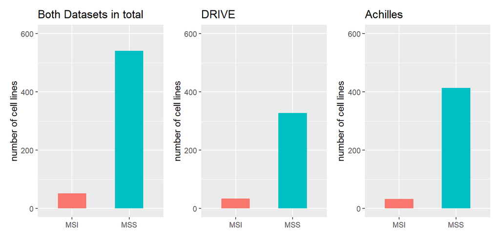

```r
# count rows of MSI and MSS classified cell lines
counts_class <- data.frame(table(data_suppl$CCLE_MSI))

# count rows of MSI and MSS classified cell lines for each dataset separately
counts_class_DRIVE <- data.frame(table(data_suppl[!is.na(data_suppl$DRIVE_WRN_D2),]$CCLE_MSI))
counts_class_Achilles <- data.frame(table(data_suppl[!is.na(data_suppl$CRISPR_WRN_CERES),]$CCLE_MSI))

# create plots
# define limits on y axis
limits <- c(0,600)

bar_chart_total <- ggplot(data=counts_class, aes(x=Var1, y=Freq, fill=Var1)) +
  theme(legend.position = "none") +
  geom_bar(stat = "identity", width = 0.5) +
  ggtitle("Both Datasets in total") +
  labs(x="",y="number of cell lines") +
  coord_cartesian(ylim = limits)

bar_chart_DRIVE <- ggplot(data=counts_class_DRIVE, aes(x=Var1, y=Freq, fill=Var1)) +
  theme(legend.position = "none") +
  geom_bar(stat = "identity", width = 0.5) +
  ggtitle("DRIVE") +
  labs(x="",y="number of cell lines") +
  coord_cartesian(ylim = limits)

bar_chart_Achilles <- ggplot(data=counts_class_Achilles, aes(x=Var1, y=Freq, fill=Var1)) +
  theme(legend.position = "none") +
  geom_bar(stat = "identity", width = 0.5) +
  ggtitle("Achilles") +
  labs(x="",y="number of cell lines") +
  coord_cartesian(ylim = limits)

bar_chart_total + bar_chart_DRIVE + bar_chart_Achilles
```

## Cell Lines in DRIVE and Achilles

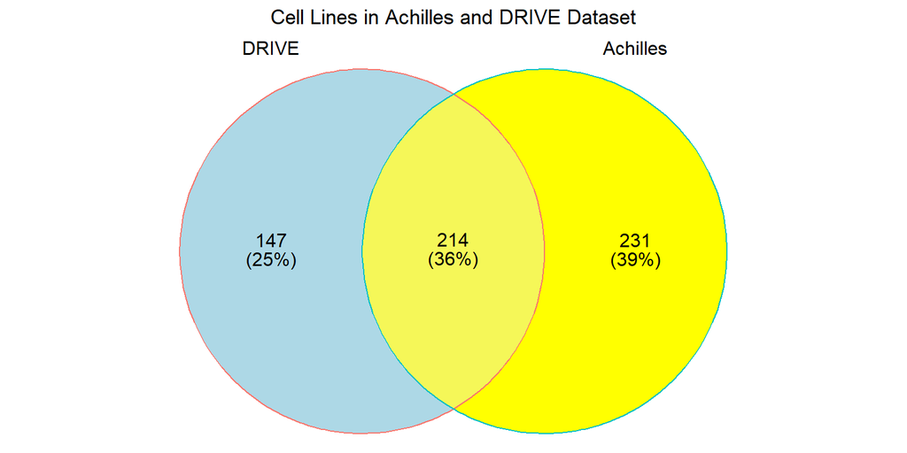

```r
DRIVE <- data_suppl[!is.na(data_suppl$DRIVE_WRN_D2),]$CCLE_ID
Achilles <- data_suppl[!is.na(data_suppl$CRISPR_WRN_CERES),]$CCLE_ID
all <- list(DRIVE=DRIVE, Achilles=Achilles)
ggVennDiagram(all, label_alpha = 0) +
  ggplot2::scale_fill_gradient(low="lightblue",high = "yellow") +
  theme(legend.position = "none", plot.title = element_text(hjust = 0.5)) +
  ggtitle('Cell Lines in Achilles and DRIVE Dataset')
```

## Correlation of Achilles and DRIVE

For quality control, I plotted the dependency scores of WRN which are present in both datasets against each other. The dependency scores of WRN from Achilles significantly correlate with the scores in DRIVE with the Pearson correlation coefficient 0.56. Since the Pearson correlation coefficient is not very high, the analysis should be performed separately to the two datasetsinstead of using the mean values.

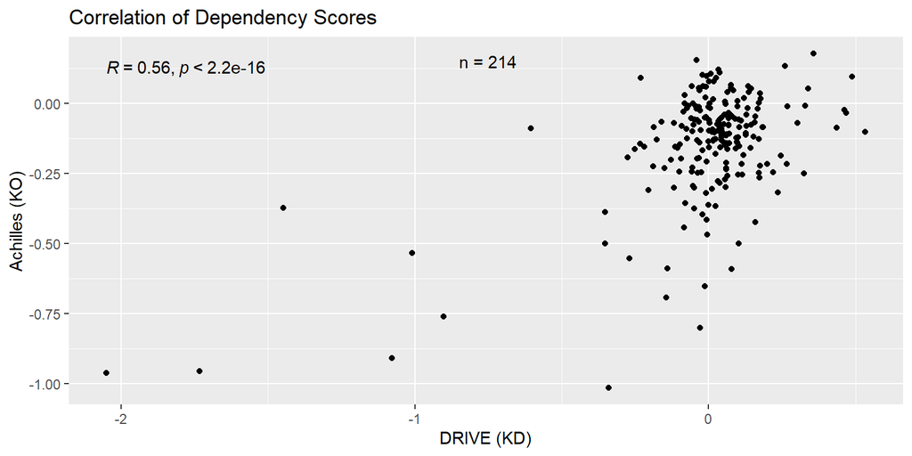

```r
# extract dependency scores
dep_scores <- data_suppl %>% select(5,6)
# remove rows with NA
dep_scores <- na.omit(dep_scores)
# create scatter plot
ggplot(dep_scores, aes(x=DRIVE_WRN_D2, y=CRISPR_WRN_CERES)) +
  geom_point() + stat_cor() +
  xlab("DRIVE (KD)") + ylab("Achilles (KO)") +
  ggtitle('Correlation of Dependency Scores') +
  annotate("text", x = -0.75, y = 0.15, label = paste("n =", nrow(dep_scores)))
```

Given the Venn diagram and the correlation of dependency scores, I decided to perform the analysis separately for both datasets.

## Dependency Score Distributions

To choose the appropriate test method, I plotted the distributions of the dependency scores for WRN in MSS and MSI cells separately as histograms. The dependency scores in MSI cell lines show a significantly greater variance. The result indicates that the MSS cell lines are normally distributed, whereas the MSI cell lines are not. This speaks against a standard t-test, which requires normally distributed data.

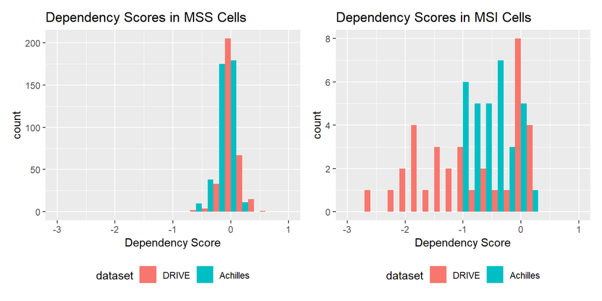

```r
# create MSI/MSS specific subsets with dependency scores
dep_scores <- data_suppl %>% select(1,4,5,6)
colnames(dep_scores) <- c("CCLE_ID", "CCLE_MSI", "DRIVE", "Achilles")
dep_scores <- melt(data = dep_scores, id.vars = c("CCLE_ID","CCLE_MSI"))
colnames(dep_scores) <- c("CCLE_ID", "CCLE_MSI", "dataset", "dep_score")
dep_scores <- dep_scores[!is.na(dep_scores$dep_score),]
dep_scores_mss <- data.frame(dep_scores[dep_scores$CCLE_MSI=="MSS",])
dep_scores_msi <- data.frame(dep_scores[dep_scores$CCLE_MSI=="MSI",])

# create plots for MSS and MSI cells separately
limits <- c(-3,1) # add limits in x axis

plot_mss <- ggplot(data = dep_scores_mss, aes(x=dep_score, fill=dataset)) +
  geom_histogram(binwidth = 0.2, position = "dodge") +
  coord_cartesian(xlim = limits) +
  xlab("Dependency Score") +
  ggtitle("Dependency Scores in MSS Cells") +
  theme(legend.position="bottom")

plot_msi <- ggplot(data = dep_scores_msi, aes(x=dep_score, fill=dataset)) +
  geom_histogram(binwidth = 0.2, position = "dodge") +
  coord_cartesian(xlim = limits) +
  xlab("Dependency Score") +
  ggtitle("Dependency Scores in MSI Cells") +
  theme(legend.position="bottom")

plot_mss + plot_msi
```

In order to follow up on the previous assumption that the scores are not normally distributed, I visualized the distribution of the scores as a density plot. Indeed, the scores do not seem to be normally distributed. One possible test in this case would be the wilcoxon test.

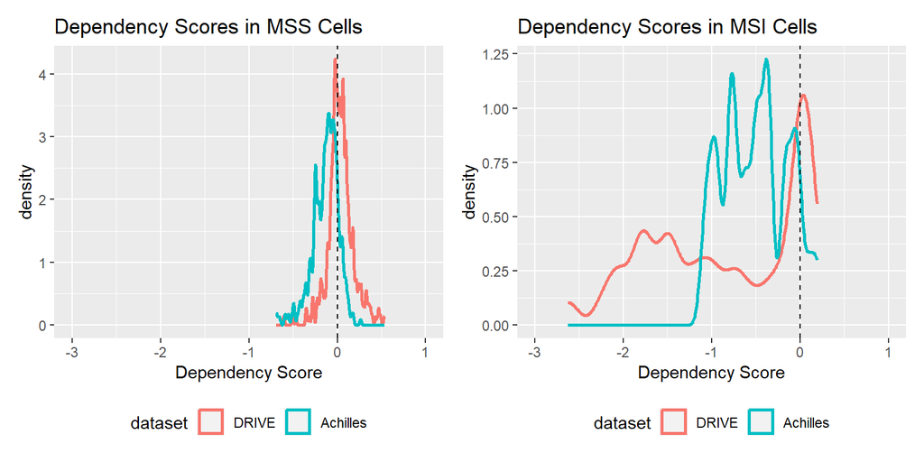

```r
plot_mss <- ggplot(data = dep_scores_mss, aes(x=dep_score, color=dataset)) +
  geom_density(linewidth=1, adjust = 0.3) +
  coord_cartesian(xlim = limits) +
  xlab("Dependency Score") +
  ggtitle("Dependency Scores in MSS Cells") +
  theme(legend.position="bottom") +
  geom_vline(xintercept = 0, linetype=2)

plot_msi <- ggplot(data = dep_scores_msi, aes(x=dep_score, color=dataset)) +
  geom_density(linewidth=1, adjust = 0.3) +
  coord_cartesian(xlim = limits) +
  xlab("Dependency Score") +
  ggtitle("Dependency Scores in MSI Cells") +
  theme(legend.position="bottom") +
  geom_vline(xintercept = 0, linetype=2)

plot_mss + plot_msi
```

To check that the different distributions are not due to the different dataset sizes, I plotted the results in boxplots and tested whether the scores come from the same distribution. The p-value is significantly low in both datasets. This suggests that MSI cell lines and MSS cell lines are differently dependent on WRN.

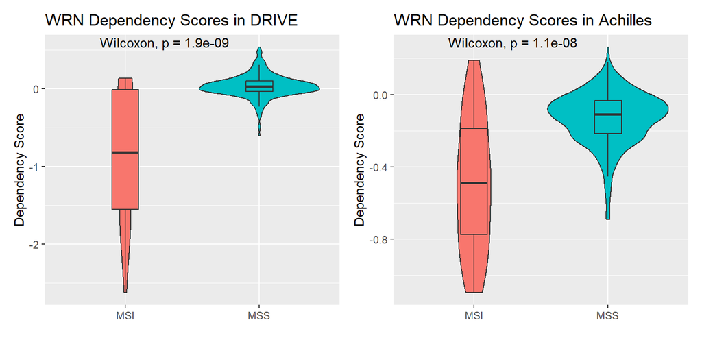

```r
# extract DRIVE and Achilles data separately with classifications
dep_scores_drive_with_class <- na.omit(data_suppl %>% select(4,5))
dep_scores_achilles_with_class <- na.omit(data_suppl %>% select(4,6))

box_plot_drive <- ggplot(dep_scores_drive_with_class, aes(x = CCLE_MSI, y = DRIVE_WRN_D2, fill = CCLE_MSI)) +
  geom_violin() +
  ggtitle("WRN Dependency Scores in DRIVE") +
  theme(legend.position = "none") +
  geom_boxplot(outlier.shape = NA, show.legend = F,width = 0.2, position = position_dodge(width = 0.9)) +
  stat_compare_means(method = "wilcox.test") +
  xlab("") + ylab("Dependency Score")

box_plot_achilles <- ggplot(dep_scores_achilles_with_class, aes(x = CCLE_MSI, y = CRISPR_WRN_CERES, fill = CCLE_MSI)) +
  theme(legend.position = "none") +
  geom_violin() +
  ggtitle("WRN Dependency Scores in Achilles") +
  geom_boxplot(outlier.shape = NA, show.legend = F,width = 0.2, position = position_dodge(width = 0.9)) +
  stat_compare_means(method = "wilcox.test") +
  xlab("") + ylab("Dependency Score")

box_plot_drive + box_plot_achilles
```

## Comparing WRN and ABHD1

As a comparison, I plotted the distributions of dependency scores for the randomly selected gene ABHD1 in Achilles. The dependency scores of WRN are generally more broadly distributed. When looking at MSI cell lines, the difference in distribution becomes much clearer.

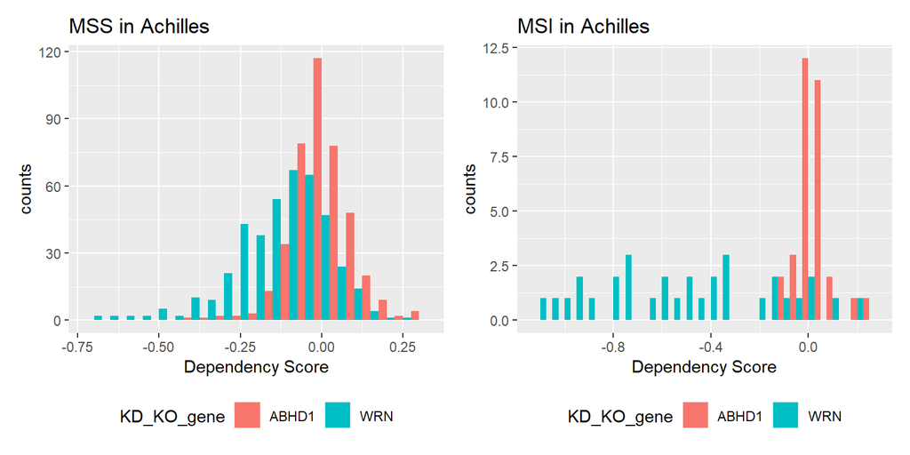

```r
# extract dependency scores for ABHD1
ABHD1_dep_scores_Achilles <- data.frame(dep_scores_18Q4_Achilles[,"ABHD1"])

# format dataset and add column for CCLE_ID
ABHD1_dep_scores_Achilles$CCLE_ID <- rownames(ABHD1_dep_scores_Achilles)
colnames(ABHD1_dep_scores_Achilles) <- c("dep_score_ABHD1","CCLE_ID")
rownames(ABHD1_dep_scores_Achilles) <- c()

# extract subset containing CCLE_IDs, dependency scores and MSI/MSS classifications
dep_scores_Achilles <- data_suppl %>% select(1,4,6)

# merge with dependency scores of ABHD1
dep_scores_Achilles <- merge(ABHD1_dep_scores_Achilles, dep_scores_Achilles, by="CCLE_ID")
dep_scores_Achilles <- dep_scores_Achilles[,c(1,3,2,4)]
colnames(dep_scores_Achilles) <- c("CCLE_ID","CCLE_MSI","ABHD1", "WRN")

# melt dataset for better plotting
dep_scores_Achilles <- melt(data = dep_scores_Achilles,id.vars = c("CCLE_ID","CCLE_MSI"))
colnames(dep_scores_Achilles) <- c("CCLE_ID","CCLE_MSI","KD_KO_gene", "dep_score")

# remove rows with NAs
dep_scores_Achilles <- na.omit(dep_scores_Achilles)

# create density plot for MSS cells
plot_mss <- ggplot(data=dep_scores_Achilles[dep_scores_Achilles$CCLE_MSI=="MSS",],aes(x=dep_score, fill=KD_KO_gene)) +
  geom_histogram(binwidth = 0.05, position = "dodge") +
  ggtitle("MSS in Achilles") +
  xlab("Dependency Score") + ylab("counts") +
  theme(legend.position="bottom")

# create density plot for MSI cells
plot_msi <- ggplot(data=dep_scores_Achilles[dep_scores_Achilles$CCLE_MSI=="MSI",],aes(x=dep_score, fill=KD_KO_gene)) +
  geom_histogram(binwidth = 0.05, position = "dodge") +
  ggtitle("MSI in Achilles") +
  xlab("Dependency Score") + ylab("counts") +
  theme(legend.position="bottom")

# plot results
plot_mss + plot_msi
```

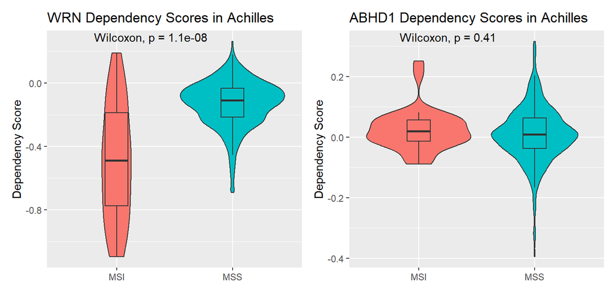

```r
dep_scores_Achilles_WRN <- dep_scores_Achilles[dep_scores_Achilles$KD_KO_gene=="WRN",]
dep_scores_Achilles_ABHD1 <- dep_scores_Achilles[dep_scores_Achilles$KD_KO_gene=="ABHD1",]

box_plot_WRN <- ggplot(dep_scores_Achilles_WRN, aes(x = CCLE_MSI, y = dep_score, fill = CCLE_MSI)) +
  geom_violin() +
  ggtitle("WRN Dependency Scores in Achilles") +
  theme(legend.position = "none") +
  geom_boxplot(outlier.shape = NA, show.legend = F,width = 0.2, position = position_dodge(width = 0.9)) +
  stat_compare_means(method = "wilcox.test") +
  ylab("Dependency Score") + xlab("")

box_plot_ABHD1 <- ggplot(dep_scores_Achilles_ABHD1, aes(x = CCLE_MSI, y = dep_score, fill = CCLE_MSI)) +
  theme(legend.position = "none") +
  geom_violin() +
  ggtitle("ABHD1 Dependency Scores in Achilles") +
  geom_boxplot(outlier.shape = NA, show.legend = F,width = 0.2, position = position_dodge(width = 0.9)) +
  stat_compare_means(method = "wilcox.test") +
  ylab("Dependency Score") + xlab("")

box_plot_WRN + box_plot_ABHD1
```

## Summary

We could see, that the analysis should be done separately for both datasets. The test method has to consider different samples sizes and sample distributions. We have also seen that, unlike other genes, the dependency scores for WRN come from different distributions. This gives a first indication that the altered expression of the WRN gene, in contrast to other genes, affects MSI and MSS cell lines differently, as claimed by E. M. Chan et al. (2018).

# Data Analysis

## Mean Differences

To reproduce the workflow by E. M. Chan et al. (2018), I calculated the differences of the mean values of dependency sores for MSI and MSS cell lines for every gene.

```r
# transform matrix to dataframe
dep_scores_18Q4_Achilles_df <- data.frame(dep_scores_18Q4_Achilles)

# add column with CCLE ID
dep_scores_18Q4_Achilles_df <- cbind(CCLE_ID = rownames(dep_scores_18Q4_Achilles_df), dep_scores_18Q4_Achilles_df)
rownames(dep_scores_18Q4_Achilles_df) <- NULL

# add CCLE_MSI classification to each cell line
classifications <- data_suppl %>% select(1,4)
dep_scores_18Q4_Achilles_df <- merge(dep_scores_18Q4_Achilles_df, classifications, by="CCLE_ID")

# split dataset in MSI and MSS
dep_scores_18Q4_Achilles_msi <- dep_scores_18Q4_Achilles_df[dep_scores_18Q4_Achilles_df$CCLE_MSI=="MSI",c(-1,-ncol(dep_scores_18Q4_Achilles_df))]
dep_scores_18Q4_Achilles_mss <- dep_scores_18Q4_Achilles_df[dep_scores_18Q4_Achilles_df$CCLE_MSI=="MSS",c(-1,-ncol(dep_scores_18Q4_Achilles_df))]

# calculate means
means_msi_Achilles <- data.frame(colMeans(dep_scores_18Q4_Achilles_msi))
means_mss_Achilles <- data.frame(colMeans(dep_scores_18Q4_Achilles_mss))

# calculate differences MSI-MSS
mean_differences_Achilles <- means_msi_Achilles - means_mss_Achilles
colnames(mean_differences_Achilles) <- "MSI_MSS"

head(mean_differences_Achilles)
```

```
##              MSI_MSS
## A1BG    -0.012751857
## A1CF    -0.011034320
## A2M     -0.004455003
## A2ML1   -0.030888185
## A3GALT2  0.012621853
## A4GALT   0.022104494
```

```r
# do the same for DRIVE
dep_scores_18Q4_DRIVE_df <- data.frame(dep_scores_18Q4_DRIVE)
dep_scores_18Q4_DRIVE_df <- cbind(CCLE_ID = rownames(dep_scores_18Q4_DRIVE_df), dep_scores_18Q4_DRIVE_df)
rownames(dep_scores_18Q4_DRIVE_df) <- NULL
dep_scores_18Q4_DRIVE_df <- merge(dep_scores_18Q4_DRIVE_df, classifications, by="CCLE_ID")
dep_scores_18Q4_DRIVE_msi <- dep_scores_18Q4_DRIVE_df[dep_scores_18Q4_DRIVE_df$CCLE_MSI=="MSI",c(-1,-ncol(dep_scores_18Q4_DRIVE_df))]
dep_scores_18Q4_DRIVE_mss <- dep_scores_18Q4_DRIVE_df[dep_scores_18Q4_DRIVE_df$CCLE_MSI=="MSS",c(-1,-ncol(dep_scores_18Q4_DRIVE_df))]
means_msi_DRIVE <- data.frame(colMeans(dep_scores_18Q4_DRIVE_msi, na.rm = TRUE))
means_mss_DRIVE <- data.frame(colMeans(dep_scores_18Q4_DRIVE_mss, na.rm = TRUE))
mean_differences_DRIVE <- means_msi_DRIVE - means_mss_DRIVE
colnames(mean_differences_DRIVE) <- "MSI_MSS"
```

## Welch Test

I calculated the p-values of the dependency scores for MSI and MSS cell lines for every gene using the welch test. (Actually, the welch test is not suitable for this data, but I do it as comparison.)

```r
test_results_welch_Achilles <- col_t_welch(dep_scores_18Q4_Achilles_msi, dep_scores_18Q4_Achilles_mss)
p_values_welch_Achilles <- data.frame(matrix(NA, nrow = nrow(test_results_welch_Achilles), ncol = 2))
colnames(p_values_welch_Achilles) <- c('gene','p_value')
p_values_welch_Achilles$gene <- rownames(test_results_welch_Achilles)
p_values_welch_Achilles$p_value <- test_results_welch_Achilles$pvalue
head(p_values_welch_Achilles)
```

```
##      gene   p_value
## 1    A1BG 0.6786948
## 2    A1CF 0.4169386
## 3     A2M 0.7640275
## 4   A2ML1 0.1045845
## 5 A3GALT2 0.6552343
## 6  A4GALT 0.2234736
```

```r
test_results_welch_DRIVE <- col_t_welch(dep_scores_18Q4_DRIVE_msi, dep_scores_18Q4_DRIVE_mss)
p_values_welch_DRIVE <- data.frame(matrix(NA, nrow = nrow(test_results_welch_DRIVE), ncol = 2))
colnames(p_values_welch_DRIVE) <- c('gene','p_value')
p_values_welch_DRIVE$gene <- rownames(test_results_welch_DRIVE)
p_values_welch_DRIVE$p_value <- test_results_welch_DRIVE$pvalue
```

I plotted the mean value differences of the dependency scores in MSI and MSS cell lines against the corresponding p-values. The horizontal line marks the significance level of 5%. As the figure shown, the WRN have a great mean value difference and a small adjusted p-value. The cell lines depend to different degrees on some genes. This difference is greatest for WRN.

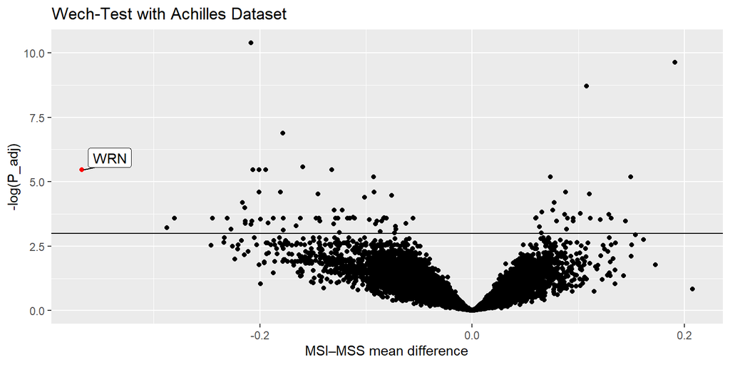

```r
# transform p-values
p_adj_welch_Achilles <- p_values_welch_Achilles
p_adj_welch_Achilles$p_value <- p.adjust(p_values_welch_Achilles$p_value, method = "BH")
p_values_welch_log_Achilles <- p_adj_welch_Achilles
p_values_welch_log_Achilles$p_value <- NULL
p_values_welch_log_Achilles$log <- -log(p_adj_welch_Achilles$p_value)

# create data structure for mean differences and p-values
results_Achilles <- cbind(p_values_welch_log_Achilles, mean_differences_Achilles)
rownames(results_Achilles) <- NULL

# define labeled genes
results_Achilles$to_label <- ""
results_Achilles$to_label[results_Achilles$gene == "WRN"] <- "WRN"

# do the same for DRIVE
p_adj_welch_DRIVE <- p_values_welch_DRIVE
p_adj_welch_DRIVE$p_value <- p.adjust(p_values_welch_DRIVE$p_value, method = "BH")
p_values_welch_log_DRIVE <- p_adj_welch_DRIVE
p_values_welch_log_DRIVE$p_value <- NULL
p_values_welch_log_DRIVE$log <- -log(p_adj_welch_DRIVE$p_value)

results_DRIVE <- cbind(p_values_welch_log_DRIVE, mean_differences_DRIVE)
rownames(results_DRIVE) <- NULL

results_DRIVE$to_label <- ""
results_DRIVE$to_label[results_DRIVE$gene == "WRN"] <- "WRN"

# plots
result_plot_Achilles <- ggplot(data=results_Achilles, aes(x=MSI_MSS, y=log, label=to_label)) +
  geom_point() +
  geom_point(data = results_Achilles[results_Achilles$to_label == "WRN",], color="red") +
  xlab('MSI–MSS mean difference') +
  ylab('-log(P_adj)') +
  geom_label_repel() +
  geom_hline(yintercept=-log(0.05)) +
  ggtitle("Wech-Test with Achilles Dataset")

result_plot_DRIVE <- ggplot(data=results_DRIVE, aes(x=MSI_MSS, y=log, label=to_label)) +
  geom_point() +
  geom_point(data = results_DRIVE[results_DRIVE$to_label == "WRN",], color="red") +
  xlab('MSI–MSS mean difference') +
  ylab('-log(P_adj)') +
  geom_label_repel() +
  geom_hline(yintercept=-log(0.05)) +
  ggtitle("Wech-Test with DRIVE Dataset")

# plot both
result_plot_Achilles
```

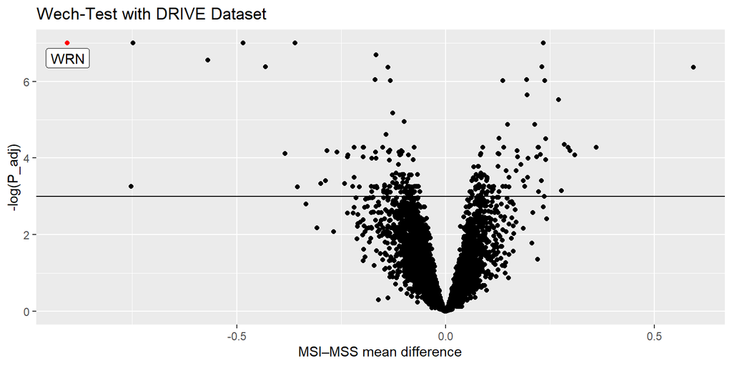

```r
result_plot_DRIVE
```

## Wilcoxon Test

Again, I calculated the p-values of the dependency scores for MSI and MSS cell lines for every gene, but using the wilcoxon test. The wilcoxon test, unlike the Welch-Test, takes into account that the MSI samples are not normally distributed.

```r
# Achilles
test_results_wilc_Achilles <- col_wilcoxon_twosample(dep_scores_18Q4_Achilles_msi, dep_scores_18Q4_Achilles_mss)
p_values_wilc_Achilles <- data.frame(matrix(NA, nrow = nrow(test_results_wilc_Achilles), ncol = 2))
colnames(p_values_wilc_Achilles) <- c('gene','p_value')
p_values_wilc_Achilles$gene <- rownames(test_results_wilc_Achilles)
p_values_wilc_Achilles$p_value <- test_results_wilc_Achilles$pvalue
head(p_values_wilc_Achilles)
```

```
##      gene    p_value
## 1    A1BG 0.12701036
## 2    A1CF 0.47338419
## 3     A2M 0.91534507
## 4   A2ML1 0.06769078
## 5 A3GALT2 0.20951517
## 6  A4GALT 0.09891584
```

```r
# DRIVE
test_results_wilc_DRIVE <- col_wilcoxon_twosample(dep_scores_18Q4_DRIVE_msi, dep_scores_18Q4_DRIVE_mss)
p_values_wilc_DRIVE <- data.frame(matrix(NA, nrow = nrow(test_results_wilc_DRIVE), ncol = 2))
colnames(p_values_wilc_DRIVE) <- c('gene','p_value')
p_values_wilc_DRIVE$gene <- rownames(test_results_wilc_DRIVE)
p_values_wilc_DRIVE$p_value <- test_results_wilc_DRIVE$pvalue
```

I repeated the plot with the mean differences of the dependency scores in MSI and MSS cell lines against the corresponding p-values. Using the appropriate test method, the p-value for WRN is even smaller, which means that the result is more reliable.

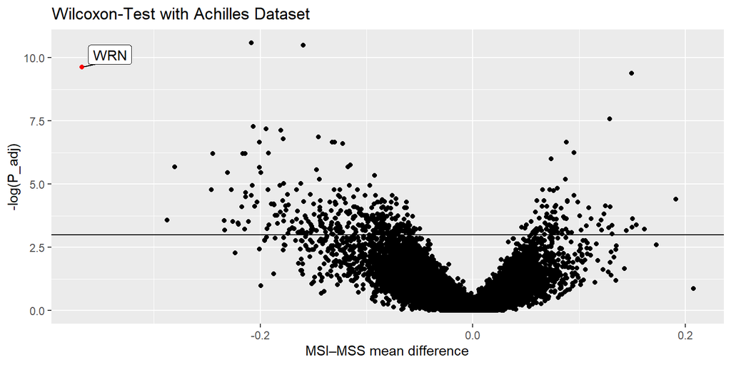

```r
# transform p-values
p_adj_wilc_Achilles <- p_values_wilc_Achilles
p_adj_wilc_Achilles$p_value <- p.adjust(p_values_wilc_Achilles$p_value, method = "BH")
p_values_wilc_log_Achilles <- p_adj_wilc_Achilles
p_values_wilc_log_Achilles$p_value <- NULL
p_values_wilc_log_Achilles$log <- -log(p_adj_wilc_Achilles$p_value)

# create data structure for mean differences and p-values
results_wilc_Achilles <- cbind(p_values_wilc_log_Achilles, mean_differences_Achilles)
rownames(results_wilc_Achilles) <- NULL

# define labeled genes
results_wilc_Achilles$to_label <- ""
results_wilc_Achilles$to_label[results_wilc_Achilles$gene == "WRN"] <- "WRN"

# do the same for DRIVE
p_adj_wilc_DRIVE <- p_values_wilc_DRIVE
p_adj_wilc_DRIVE$p_value <- p.adjust(p_values_wilc_DRIVE$p_value, method = "BH")
p_values_wilc_log_DRIVE <- p_adj_wilc_DRIVE
p_values_wilc_log_DRIVE$p_value <- NULL
p_values_wilc_log_DRIVE$log <- -log(p_adj_wilc_DRIVE$p_value)

results_wilc_DRIVE <- cbind(p_values_wilc_log_DRIVE, mean_differences_DRIVE)
rownames(results_wilc_DRIVE) <- NULL

results_wilc_DRIVE$to_label <- ""
results_wilc_DRIVE$to_label[results_wilc_DRIVE$gene == "WRN"] <- "WRN"

# plots
ggplot(data=results_wilc_Achilles, aes(x=MSI_MSS, y=log, label=to_label)) +
  geom_point() +
  geom_point(data = results_wilc_Achilles[results_wilc_Achilles$to_label == "WRN",], color="red") +
  xlab('MSI–MSS mean difference') +
  ylab('-log(P_adj)') +
  geom_label_repel() +
  geom_hline(yintercept=-log(0.05)) +
  ggtitle("Wilcoxon-Test with Achilles Dataset")
```

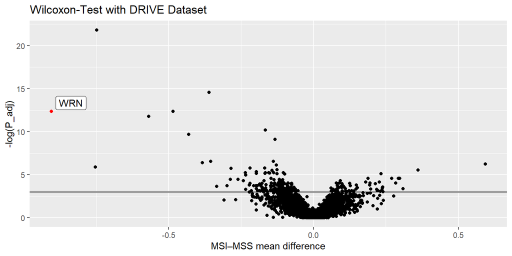

```r
ggplot(data=results_wilc_DRIVE, aes(x=MSI_MSS, y=log, label=to_label)) +
  geom_point() +
  geom_point(data = results_wilc_DRIVE[results_wilc_DRIVE$to_label == "WRN",], color="red") +
  xlab('MSI–MSS mean difference') +
  ylab('-log(P_adj)') +
  geom_label_repel() +
  geom_hline(yintercept=-log(0.05)) +
  ggtitle("Wilcoxon-Test with DRIVE Dataset")
```

## Bayes moderated t-stats

Now I calculated the p-values using Bayes moderated t-stats using the R package limma (Ritchie et al. 2015) as in E. M. Chan et al. (2018) and plotted them against the corresponding mean differences. With this recommended test method, I could reproduce the result by E. M. Chan et al. (2018).

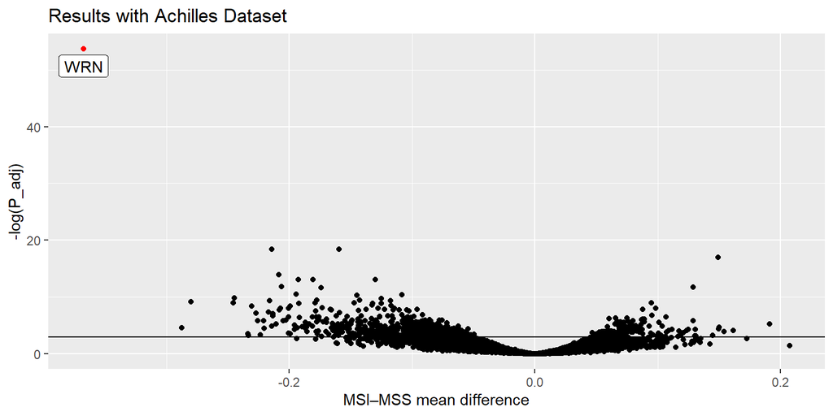

```r
# calculate p-values
vec_Achilles <- dep_scores_18Q4_Achilles_df$CCLE_MSI
mat_Achilles <- dep_scores_18Q4_Achilles_df
mat_Achilles$CCLE_MSI <- NULL
rownames(mat_Achilles) <- mat_Achilles$CCLE_ID
mat_Achilles$CCLE_ID <- NULL
mat_Achilles <- as.matrix(mat_Achilles)

design_Achilles <- model.matrix(~vec_Achilles)
fit_Achilles <- lmFit(t(mat_Achilles),design=design_Achilles)
fit_Achilles <- eBayes(fit = fit_Achilles)
test_results_bayes_Achilles <- topTable(fit = fit_Achilles, n=Inf, coef = 2, sort.by = "none")

p_adj_bayes_Achilles <- data.frame(matrix(NA, nrow = nrow(test_results_bayes_Achilles), ncol = 2))
colnames(p_adj_bayes_Achilles) <- c('gene','p_adj')
p_adj_bayes_Achilles$gene <- rownames(test_results_bayes_Achilles)
p_adj_bayes_Achilles$p_adj <- test_results_bayes_Achilles$adj.P.Val

# transform p-values
p_adj_bayes_log_Achilles <- p_adj_bayes_Achilles
p_adj_bayes_log_Achilles$p_adj <- NULL
p_adj_bayes_log_Achilles$log <- -log(p_adj_bayes_Achilles$p_adj)

# create data structure for mean differences and p-values
results_bayes_Achilles <- cbind(p_adj_bayes_log_Achilles, mean_differences_Achilles)
rownames(results_bayes_Achilles) <- NULL

# define labeled genes
results_bayes_Achilles$to_label <- ""
results_bayes_Achilles$to_label[results_bayes_Achilles$gene == "WRN"] <- "WRN"

# do the same with DRIVE
vec_DRIVE <- dep_scores_18Q4_DRIVE_df$CCLE_MSI
mat_DRIVE <- dep_scores_18Q4_DRIVE_df
mat_DRIVE$CCLE_MSI <- NULL
rownames(mat_DRIVE) <- mat_DRIVE$CCLE_ID
mat_DRIVE$CCLE_ID <- NULL
mat_DRIVE <- as.matrix(mat_DRIVE)

design_DRIVE <- model.matrix(~vec_DRIVE)
fit_DRIVE <- lmFit(t(mat_DRIVE),design=design_DRIVE)
fit_DRIVE <- eBayes(fit = fit_DRIVE)
test_results_bayes_DRIVE <- topTable(fit = fit_DRIVE, n=Inf, coef = 2, sort.by = "none")

p_adj_bayes_DRIVE <- data.frame(matrix(NA, nrow = nrow(test_results_bayes_DRIVE), ncol = 2))
colnames(p_adj_bayes_DRIVE) <- c('gene','p_adj')
p_adj_bayes_DRIVE$gene <- rownames(test_results_bayes_DRIVE)
p_adj_bayes_DRIVE$p_adj <- test_results_bayes_DRIVE$adj.P.Val

p_adj_bayes_log_DRIVE <- p_adj_bayes_DRIVE
p_adj_bayes_log_DRIVE$p_adj <- NULL
p_adj_bayes_log_DRIVE$log <- -log(p_adj_bayes_DRIVE$p_adj)

results_bayes_DRIVE <- cbind(p_adj_bayes_log_DRIVE, mean_differences_DRIVE)
rownames(results_bayes_DRIVE) <- NULL

results_bayes_DRIVE$to_label <- ""
results_bayes_DRIVE$to_label[results_bayes_DRIVE$gene == "WRN"] <- "WRN"

# plots
ggplot(data=results_bayes_Achilles, aes(x=MSI_MSS,y=log, label=to_label)) +
  geom_point() +
  geom_point(data = results_bayes_Achilles[results_bayes_Achilles$to_label == "WRN",], color="red") +
  xlab('MSI–MSS mean difference') +
  ylab('-log(P_adj)') +
  geom_label_repel() +
  geom_hline(yintercept=-log(0.05)) +
  ggtitle("Results with Achilles Dataset")
```

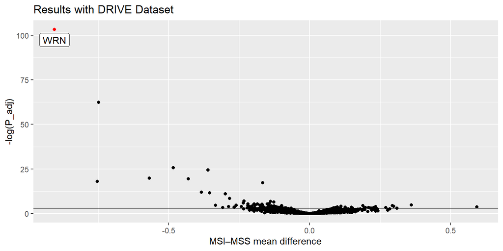

```r
ggplot(data=results_bayes_DRIVE, aes(x=MSI_MSS,y=log, label=to_label)) +
  geom_point() +
  geom_point(data = results_bayes_DRIVE[results_bayes_DRIVE$to_label == "WRN",], color="red") +
  xlab('MSI–MSS mean difference') +
  ylab('-log(P_adj)') +
  geom_label_repel() +
  geom_hline(yintercept=-log(0.05)) +
  ggtitle("Results with DRIVE Dataset")
```

## Summary

I used three different test methods to validate the result for both Achilles and DRIVE separately. I could reproduce the result by E. M. Chan et al. (2018) using the Bayes moderated t-stats. WRN also achieved a low p-value with a large mean difference using the welch and wilcoxon tests. The result suggests that WRN is indeed a promising target for synthetic lethality.

Chan, Denise A, and Amato J Giaccia. 2011. “Harnessing Synthetic Lethal Interactions in Anticancer Drug Discovery.” *Nature Reviews Drug Discovery* 10 (5): 351–64.

Chan, Edmond M., Tsukasa Shibue, James McFarland, Benjamin Gaeta, Justine S. McPartlan, Mahmoud Ghandi, Jie Bin Liu, et al. 2018. “WRN Helicase Is a Synthetic Lethal Target in Microsatellite Unstable Cancers.” *bioRxiv*. https://doi.org/10.1101/502070.

Ritchie, Matthew E., Belinda Phipson, Di Wu, Yifang Hu, Charity W. Law, Wei Shi, and Gordon K. Smyth. 2015. “limma powers differential expression analyses for RNA-sequencing and microarray studies.” *Nucleic Acids Research* 43 (7): e47–47. https://doi.org/10.1093/nar/gkv007.